# prediction - Pratical Machine learning

Aly TIMITE

23/09/2018

### Introduction

Using devices such as Jawbone Up, Nike FuelBand, and Fitbit it is now possible to collect a large amount of data about personal activity relatively inexpensively. These type of devices are part of the quantified self movement – a group of enthusiasts who take measurements about themselves regularly to improve their health, to find patterns in their behavior, or because they are tech geeks. One thing that people regularly do is quantify how much of a particular activity they do, but they rarely quantify how well they do it. In this project, your goal will be to use data from accelerometers on the belt, forearm, arm, and dumbell of 6 participants. They were asked to perform barbell lifts correctly and incorrectly in 5 different ways. More information is available from the website here: http://groupware.les.inf.puc-rio.br/har (see the section on the Weight Lifting Exercise Dataset).

## Loading data from source

We have to download data from following sources:

https://d396qusza40orc.cloudfront.net/predmachlearn/pml-training.csv for training data and https://d396qusza40orc.cloudfront.net/predmachlearn/pml-testing.csv for testing data. The data for this project come from this source: http://groupware.les.inf.puc-rio.br/har.

```r
library(caret)
```

```r
library(rpart)
library(rpart.plot)
library(RColorBrewer)
library(rattle)
library(randomForest)
```

After downloading different libraries for our needs, let’s get different files from sources

```r
trainingURL <- "http://d396qusza40orc.cloudfront.net/predmachlearn/pml-training.csv"
testingURL <- "https://d396qusza40orc.cloudfront.net/predmachlearn/pml-testing.csv"

training_data <- read.csv(url(trainingURL))
testing_data <- read.csv(url(testingURL))
```

## DATA CLEANING

for cleaning data, these are the following steps: 1- Remove the 7 first features in testing data since they are related to time-series 2- Remove all columns that contains NA and remove features that are not in the testing dataset. 3- The features containing NA are the variance, mean and standard devition (SD) within each window for each feature. Since the testing dataset has no time-dependence, these values are useless and can be disregarded.

```r
clean <- names(testing_data[,colSums(is.na(testing_data)) == 0])[8:59]

# Only use "clean"  used in testing cases.
training_data <- training_data[,c(clean,"classe")]
testing_data <- testing_data[,c(clean,"problem_id")]

dim(training_data); dim(testing_data)
```

```
## [1] 19622    53
```

```
## [1] 20 53
```

## Data Partitioning

We will split our data into a training data set (60% of the total cases) and a testing data set (40% of the total cases; the latter should not be confused with the data in the testing file).

```r
set.seed(1000)

Train <- createDataPartition(training_data$classe, p=0.6, list=FALSE)
trainingset <- training_data[Train,]
testingset <- training_data[-Train,]

dim(trainingset); dim(testingset)
```

```
## [1] 11776    53
```

```
## [1] 7846   53
```

## Decision Tree Model building

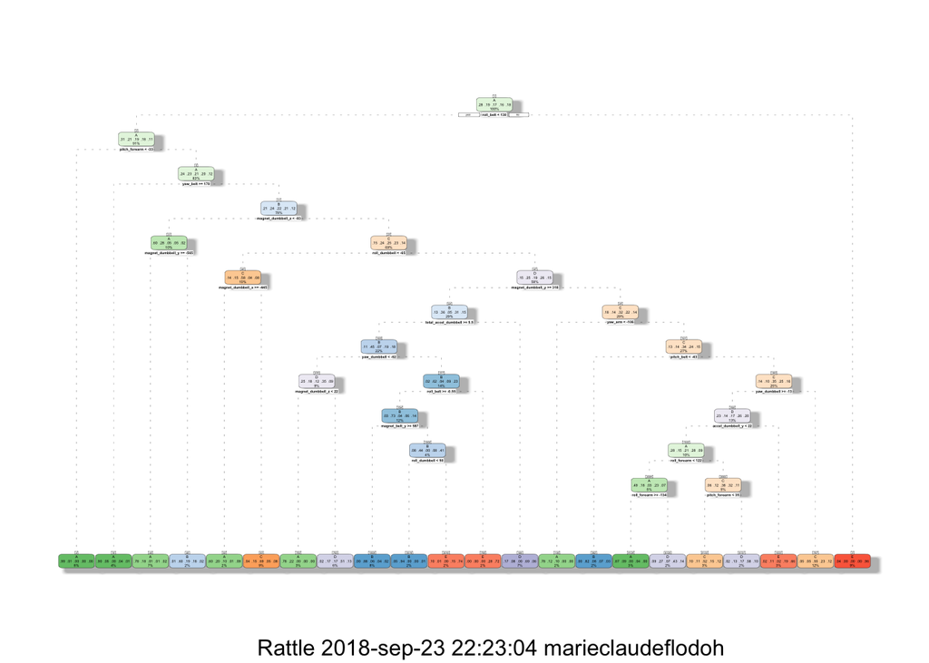

```r
DTfit <- rpart(classe ~ ., data = trainingset, method="class")
fancyRpartPlot(DTfit)
```

## Predicting with the Decision Tree Model

```r
set.seed(1000)

prediction <- predict(DTfit, testingset, type = "class")
confusionMatrix(prediction, testingset$classe)
```

```
## Confusion Matrix and Statistics
##
##           Reference
## Prediction    A    B    C    D    E
##          A 1896  240   36   47   31
##          B   14  875   80   74   19
##          C  109  183 1132  318  193
##          D  146  191  115  724  122
##          E   67   29    5  123 1077
##
## Overall Statistics
##
##                Accuracy : 0.727
##                  95% CI : (0.717, 0.7368)
##     No Information Rate : 0.2845
##     P-Value [Acc > NIR] : < 2.2e-16
##
##                   Kappa : 0.6551
##  Mcnemar's Test P-Value : < 2.2e-16
##
## Statistics by Class:
##
##                      Class: A Class: B Class: C Class: D Class: E
## Sensitivity            0.8495   0.5764   0.8275  0.56299   0.7469
## Specificity            0.9369   0.9704   0.8760  0.91250   0.9650
## Pos Pred Value         0.8427   0.8239   0.5850  0.55778   0.8278
## Neg Pred Value         0.9400   0.9052   0.9601  0.91417   0.9442
## Prevalence             0.2845   0.1935   0.1744  0.16391   0.1838
## Detection Rate         0.2417   0.1115   0.1443  0.09228   0.1373
## Detection Prevalence   0.2868   0.1354   0.2466  0.16543   0.1658
## Balanced Accuracy      0.8932   0.7734   0.8518  0.73774   0.8560
```

## Random Forest model building

With random forest model, we should expect prediction error under 3%

```r
set.seed(1000)
RFfit <- randomForest(classe ~ ., data = trainingset, ntree = 1000)
```

## Predicting with the Random Forest Model

```r
prediction1 <- predict(RFfit, testingset, type = "class")
confusionMatrix(prediction1, testingset$classe)
```

```
## Confusion Matrix and Statistics
##
##           Reference
## Prediction    A    B    C    D    E
##          A 2228   17    0    0    0
##          B    4 1496   10    0    0
##          C    0    5 1358   21    0
##          D    0    0    0 1265    3
##          E    0    0    0    0 1439
##
## Overall Statistics
##
##                Accuracy : 0.9924
##                  95% CI : (0.9902, 0.9942)
##     No Information Rate : 0.2845
##     P-Value [Acc > NIR] : < 2.2e-16
##
##                   Kappa : 0.9903
##  Mcnemar's Test P-Value : NA
##
## Statistics by Class:
##
##                      Class: A Class: B Class: C Class: D Class: E
## Sensitivity            0.9982   0.9855   0.9927   0.9837   0.9979
## Specificity            0.9970   0.9978   0.9960   0.9995   1.0000
## Pos Pred Value         0.9924   0.9907   0.9812   0.9976   1.0000
## Neg Pred Value         0.9993   0.9965   0.9985   0.9968   0.9995
## Prevalence             0.2845   0.1935   0.1744   0.1639   0.1838
## Detection Rate         0.2840   0.1907   0.1731   0.1612   0.1834
## Detection Prevalence   0.2861   0.1925   0.1764   0.1616   0.1834
## Balanced Accuracy      0.9976   0.9916   0.9943   0.9916   0.9990
```

## Predicting on the Testing Data

### Decision Tree Prediction

```r
DTprediction <- predict(DTfit, testing_data, type = "class")
DTprediction
```

```
##  1  2  3  4  5  6  7  8  9 10 11 12 13 14 15 16 17 18 19 20
##  D  A  D  A  A  C  D  D  A  A  C  C  C  A  D  E  A  D  A  B
## Levels: A B C D E
```

## Random Forest Prediction

```r
RFprediction <- predict(RFfit, testing_data, type = "class")
RFprediction
```

```
##  1  2  3  4  5  6  7  8  9 10 11 12 13 14 15 16 17 18 19 20
##  B  A  B  A  A  E  D  B  A  A  B  C  B  A  E  E  A  B  B  B
## Levels: A B C D E
```